# Prosper Loan Data Exploration

## Introduction

This project is an exploratory data analyses of the Prosper loan data set provided by Udacity. The data set contains information about loan listings and related variables including borrower as well as lender information. This data set contains 113,937 loans with 81 variables on each loan, including loan amount, borrower rate (or interest rate), current loan status, borrower income, and many others.

This project is aimed at providing a summary of the features of certain variables that affect status of loans with an insight on the relationships among multiple variables using summary statistics and data visualizations. As such, answers can be provided to certain key questions related to the business or real-world context of the data.

## Preliminary Wrangling

```python
# import all packages and set plots to be embedded inline
import numpy as np
import pandas as pd
import matplotlib.pyplot as plt
import seaborn as sb
%matplotlib inline
```

> Load the dataset (which is a csv file) from the website and describe its properties.

```python
# Load in the data set into a pandas dataframe
url = 'https://s3.amazonaws.com/udacity-hosted-downloads/ud651/prosperLoanData.csv'
raw_df = pd.read_csv(url)
# print a sample of 5 rows
raw_df.sample(5)
```

|  | ListingKey | ListingNumber | ListingCreationDate | CreditGrade | Term | LoanStatus | ClosedDate | BorrowerAPR | BorrowerRate | LenderYield | ... | LP_ServiceFees | LP_CollectionFees | LP_GrossPrincipalLoss | LP_NetPrincipalLoss | LP_NonPrincipalRecoverypayments | PercentFunded | Recommendations | InvestmentFromFriendsCount | InvestmentFromFriendsAmount | Investors |
| --- | --- | --- | --- | --- | --- | --- | --- | --- | --- | --- | --- | --- | --- | --- | --- | --- | --- | --- | --- | --- | --- |
| 51614 | 1E913471092595150A2827D | 437536 | 2009-12-08 12:39:32.263000000 | NaN | 36 | Completed | 2011-02-01 00:00:00 | 0.11798 | 0.1145 | 0.1045 | ... | -83.76 | 0.00 | 0.0 | 0.00 | 0.0 | 1.0 | 0 | 0 | 0.0 | 594 |
| 68799 | 07493507154490230980C45 | 492508 | 2011-02-01 20:36:04.197000000 | NaN | 36 | Completed | 2013-12-06 00:00:00 | 0.23383 | 0.1999 | 0.1899 | ... | -161.08 | 0.00 | 0.0 | 0.00 | 0.0 | 1.0 | 0 | 0 | 0.0 | 152 |
| 79534 | 1C6735939154876984634CD | 976586 | 2013-10-28 18:09:51.950000000 | NaN | 60 | Current | NaN | 0.21576 | 0.1915 | 0.1815 | ... | -46.15 | 0.00 | 0.0 | 0.00 | 0.0 | 1.0 | 0 | 0 | 0.0 | 1 |
| 46492 | EC6433926371609877AFB90 | 154320 | 2007-06-18 20:55:06.200000000 | C | 36 | Chargedoff | 2008-08-01 00:00:00 | 0.20986 | 0.2025 | 0.1725 | ... | -16.64 | -19.02 | 2568.7 | 2568.69 | 0.0 | 1.0 | 0 | 0 | 0.0 | 70 |
| 31835 | 81A8360368883190295E444 | 1230779 | 2014-03-05 08:25:19.733000000 | NaN | 60 | Current | NaN | 0.17198 | 0.1485 | 0.1385 | ... | 0.00 | 0.00 | 0.0 | 0.00 | 0.0 | 1.0 | 0 | 0 | 0.0 | 1 |

5 rows × 81 columns

```python
# Show a summary of the data set: shape, variables and non-null values
raw_df.info()
```

```
<class 'pandas.core.frame.DataFrame'>
RangeIndex: 113937 entries, 0 to 113936
Data columns (total 81 columns):
ListingKey                             113937 non-null object
ListingNumber                          113937 non-null int64
ListingCreationDate                    113937 non-null object
CreditGrade                            28953 non-null object
Term                                   113937 non-null int64
LoanStatus                             113937 non-null object
ClosedDate                             55089 non-null object
BorrowerAPR                            113912 non-null float64
BorrowerRate                           113937 non-null float64
LenderYield                            113937 non-null float64
EstimatedEffectiveYield                84853 non-null float64
EstimatedLoss                          84853 non-null float64
EstimatedReturn                        84853 non-null float64
ProsperRating (numeric)                84853 non-null float64
ProsperRating (Alpha)                  84853 non-null object
ProsperScore                           84853 non-null float64
ListingCategory (numeric)              113937 non-null int64
BorrowerState                          108422 non-null object
Occupation                             110349 non-null object
EmploymentStatus                       111682 non-null object
EmploymentStatusDuration               106312 non-null float64
IsBorrowerHomeowner                    113937 non-null bool
CurrentlyInGroup                       113937 non-null bool
GroupKey                               13341 non-null object
DateCreditPulled                       113937 non-null object
CreditScoreRangeLower                  113346 non-null float64
CreditScoreRangeUpper                  113346 non-null float64
FirstRecordedCreditLine                113240 non-null object
CurrentCreditLines                     106333 non-null float64
OpenCreditLines                        106333 non-null float64
TotalCreditLinespast7years             113240 non-null float64
OpenRevolvingAccounts                  113937 non-null int64
OpenRevolvingMonthlyPayment            113937 non-null float64
InquiriesLast6Months                   113240 non-null float64
TotalInquiries                         112778 non-null float64
CurrentDelinquencies                   113240 non-null float64
AmountDelinquent                       106315 non-null float64
```

[output cut: 31 more lines]

```
LP_CustomerPayments                    113937 non-null float64
LP_CustomerPrincipalPayments           113937 non-null float64
LP_InterestandFees                     113937 non-null float64
LP_ServiceFees                         113937 non-null float64
LP_CollectionFees                      113937 non-null float64
LP_GrossPrincipalLoss                  113937 non-null float64
LP_NetPrincipalLoss                    113937 non-null float64
LP_NonPrincipalRecoverypayments        113937 non-null float64
PercentFunded                          113937 non-null float64
Recommendations                        113937 non-null int64
InvestmentFromFriendsCount             113937 non-null int64
InvestmentFromFriendsAmount            113937 non-null float64
Investors                              113937 non-null int64
dtypes: bool(3), float64(50), int64(11), object(17)
memory usage: 68.1+ MB
```

```python
# Check for duplicates
raw_df.duplicated().sum()
```

```
0
```

There are 113,937 records and 81 columns. The variables are much more than we need for this project, hence we can select only the interesting columns to analyze; columns of interest are related to loan amount, status and ratings, interest rates and some demographics about the borrowers.

```python
# Select features of interest for this analysis into a new dataframe
loan_df = raw_df[['CreditGrade', 'Term', 'LoanStatus', 'BorrowerAPR', 'BorrowerRate',
                  'ProsperRating (Alpha)', 'ListingCategory (numeric)', 'BorrowerState', 'Occupation',
                  'EmploymentStatus', 'DebtToIncomeRatio', 'IncomeRange', 'LoanOriginalAmount',
                  'StatedMonthlyIncome']]
print(loan_df.shape)
print(loan_df.dtypes)
print(loan_df.head(5))
```

```
(113937, 14)
CreditGrade                   object
Term                           int64
LoanStatus                    object
BorrowerAPR                  float64
BorrowerRate                 float64
ProsperRating (Alpha)         object
ListingCategory (numeric)      int64
BorrowerState                 object
Occupation                    object
EmploymentStatus              object
DebtToIncomeRatio            float64
IncomeRange                   object
LoanOriginalAmount             int64
StatedMonthlyIncome          float64
dtype: object
  CreditGrade  Term LoanStatus  BorrowerAPR  BorrowerRate  \
0           C    36  Completed      0.16516        0.1580
1         NaN    36    Current      0.12016        0.0920
2          HR    36  Completed      0.28269        0.2750
3         NaN    36    Current      0.12528        0.0974
4         NaN    36    Current      0.24614        0.2085

  ProsperRating (Alpha)  ListingCategory (numeric) BorrowerState  \
0                   NaN                          0            CO
1                     A                          2            CO
2                   NaN                          0            GA
3                     A                         16            GA
4                     D                          2            MN

      Occupation EmploymentStatus  DebtToIncomeRatio     IncomeRange  \
0          Other    Self-employed               0.17  $25,000-49,999
1   Professional         Employed               0.18  $50,000-74,999
2          Other    Not available               0.06   Not displayed
3  Skilled Labor         Employed               0.15  $25,000-49,999
4      Executive         Employed               0.26       $100,000+

   LoanOriginalAmount  StatedMonthlyIncome
0                9425          3083.333333
1               10000          6125.000000
2                3001          2083.333333
3               10000          2875.000000
4               15000          9583.333333
```

Of the original 81 variables, only 14 were selected.

```python
# Make a copy of the dataframe
df = loan_df.copy()
```

```python
# Rename the variables to lowercase and separate with underscore
df = df.rename(columns= {'CreditGrade': 'credit_grade', 'Term': 'term', 'DebtToIncomeRatio': 'debt_to_income_ratio',
                         'BorrowerAPR': 'borrower_apr', 'BorrowerRate': 'borrower_rate', 'LoanStatus': 'loan_status',
                         'ProsperRating (Alpha)': 'prosper_rating', 'ListingCategory (numeric)': 'listing_category',
                         'BorrowerState': 'state', 'Occupation': 'occupation', 'EmploymentStatus': 'employment_status',
                         'StatedMonthlyIncome': 'monthly_income', 'IncomeRange': 'income_range',
                         'LoanOriginalAmount': 'amount'})
df.info()
```

```
<class 'pandas.core.frame.DataFrame'>
RangeIndex: 113937 entries, 0 to 113936
Data columns (total 14 columns):
credit_grade            28953 non-null object
term                    113937 non-null int64
loan_status             113937 non-null object
borrower_apr            113912 non-null float64
borrower_rate           113937 non-null float64
prosper_rating          84853 non-null object
listing_category        113937 non-null int64
state                   108422 non-null object
occupation              110349 non-null object
employment_status       111682 non-null object
debt_to_income_ratio    105383 non-null float64
income_range            113937 non-null object
amount                  113937 non-null int64
monthly_income          113937 non-null float64
dtypes: float64(4), int64(3), object(7)
memory usage: 12.2+ MB
```

There are two rating variables in our dataset: Credit grade and Prosper rating. Credit grade is the rating that was assigned at the time the listing went live. It is applicable for listings pre-2009 period and will only be populated for those listings. The Prosper Rating was assigned threafter and it is only applicable for loans originated after July 2009. For this analysis, both variables would be merged to a new single variable: credit rating.

```python
# Merge both variables to a new one then drop them
df['credit_rating'] = df['credit_grade'].str.cat(df['prosper_rating'], na_rep='')
df = df.drop(['credit_grade', 'prosper_rating'], axis=1)
```

Check for value counts of some categorical variables: term, income range and credit rating

```python
df.income_range.value_counts()
```

```
$25,000-49,999    32192
$50,000-74,999    31050
$100,000+         17337
$75,000-99,999    16916
Not displayed      7741
$1-24,999          7274
Not employed        806
$0                  621
Name: income_range, dtype: int64
```

```python
df.term.value_counts()
```

```
36    87778
60    24545
12     1614
Name: term, dtype: int64
```

```python
df.credit_rating.value_counts()
```

```
C     23994
B     19970
D     19427
A     17866
E     13084
HR    10443
AA     8881
NC      141
        131
Name: credit_rating, dtype: int64
```

```python
# Change these variable data types to ordinal category
ordinal_var_dict = {'income_range': ['$0','$1-24,999','$25,000-49,999','$50,000-74,999','$75,000-99,999','$100,000+',
                                     'Not employed','Not displayed'],
                    'credit_rating': ['AA','A','B','C','D','E','HR'],
                    'term': [12, 36, 60]}

for var in ordinal_var_dict:
    ordered_var = pd.api.types.CategoricalDtype(ordered = True,
                                                categories = ordinal_var_dict[var])
    df[var] = df[var].astype(ordered_var)
```

Listing category, being the listing the borrower selected when posting, is numeric. This would be translated to the equivalent category name.

```python
# Replace listing category number by name
category_name = {0:  'Not Available', 1 : 'Debt Consolidation', 2 : 'Home Improvement', 3 : 'Business', 4 : 'Personal Loan',
                 5 : 'Student Use', 6 : 'Auto', 7 : 'Other', 8 : 'Baby&Adoption', 9 : 'Boat', 10 : 'Cosmetic Procedure',
                 11 : 'Engagement Ring', 12 : 'Green Loans', 13 : 'Household Expenses', 14 : 'Large Purchases',
                 15 : 'Medical/Dental', 16 : 'Motorcycle', 17 : 'RV', 18 : 'Taxes', 19 : 'Vacation', 20 : 'Wedding Loans'}
df['listing_category'] = df['listing_category'].map(category_name)
```

```python
# Change occupation, borrower state, loan status, listing category and employment status to
# category data types
df.occupation = df.occupation.astype('category')
df.state = df.state.astype('category')
df.loan_status = df.loan_status.astype('category')
df.listing_category = df.listing_category.astype('category')
df.employment_status = df.employment_status.astype('category')
```

```python
# Check updated changes
print(df.info())
```

```
<class 'pandas.core.frame.DataFrame'>
RangeIndex: 113937 entries, 0 to 113936
Data columns (total 13 columns):
term                    113937 non-null category
loan_status             113937 non-null category
borrower_apr            113912 non-null float64
borrower_rate           113937 non-null float64
listing_category        113937 non-null category
state                   108422 non-null category
occupation              110349 non-null category
employment_status       111682 non-null category
debt_to_income_ratio    105383 non-null float64
income_range            113937 non-null category
amount                  113937 non-null int64
monthly_income          113937 non-null float64
credit_rating           113665 non-null category
dtypes: category(8), float64(4), int64(1)
memory usage: 5.2 MB
None
```

```python
# Descriptive statistical summary of the numeric variables
print(df.describe())
```

```
        borrower_apr  borrower_rate  debt_to_income_ratio        amount  \
count  113912.000000  113937.000000         105383.000000  113937.00000
mean        0.218828       0.192764              0.275947    8337.01385
std         0.080364       0.074818              0.551759    6245.80058
min         0.006530       0.000000              0.000000    1000.00000
25%         0.156290       0.134000              0.140000    4000.00000
50%         0.209760       0.184000              0.220000    6500.00000
75%         0.283810       0.250000              0.320000   12000.00000
max         0.512290       0.497500             10.010000   35000.00000

       monthly_income
count    1.139370e+05
mean     5.608026e+03
std      7.478497e+03
min      0.000000e+00
25%      3.200333e+03
50%      4.666667e+03
75%      6.825000e+03
max      1.750003e+06
```

```python
# Save the data set as a csv file
df.to_csv('loan_data_master.csv', index=False)
```

### What is the structure of your dataset?

The dataset contains 113,937 loans with 13 variables which are mainly numeric and categoric in nature. These variables are listed below:

> **Credit Rating**: This is a combination of Credit Grade and Prosper Rating The Prosper Rating assigned at the time the listing was created and it is ordered as follows: N/A, HR, E, D, C, B, A, AA.

> **Loan Status**: The current status of the loan: Cancelled, Chargedoff, Completed, Current, Defaulted, FinalPaymentInProgress, PastDue. The PastDue status will be accompanied by a delinquency bucket.

> **Borrower APR**: The Borrower's Annual Percentage Rate (APR) for the loan.

> **Loan Amount**: The origination amount of the loan.

> **Employment Status**: The employment status of the borrower at the time they posted the listing.

> **Monthly Income**: The monthly income the borrower stated at the time the listing was created.

> **Term**: The length of the loan expressed in months.

> **Income Range**: The income range of the borrower at the time the listing was created.

> **Listing Category**: The category that uniquely identifies the listing to the public as displayed on the website.

> **Occupation**: The Occupation selected by the Borrower at the time they created the listing.

> **Debt to Income Ratio**: The debt to income ratio of the borrower at the time the credit profile was pulled. This value is Null if the debt to income ratio is not available. This value is capped at 10.01 (any debt to income ratio larger than 1000% will be returned as 1001%).

> **State**: The two letter abbreviation of the state of the address of the borrower at the time the Listing was created.

> **Borrower Rate**: The Borrower's interest rate for this loan.

### What is/are the main feature(s) of interest in your dataset?

In this data set, I am interested in the factors affect that loan status and credit rating.

### What features in the dataset do you think will help support your investigation into your feature(s) of interest?

Loan status and credit rating have similar supporting factors since loans with good credit rating have a low tendency of default. The most important factors are borrower's APR (or interest rate), loan amount, income range, term and employment status. Other features we would review include debt-to-income ratio, listing category, borrower's state, monthly income and occupation.

## Univariate Exploration

In this section, I would be looking at the distribution of all the variables of the data set.

### What is the Distribution of Loan Status?

First I would look at loan status, being the main variable of my analysis. There are a lot of categories on this variable which I would reduce by aggregating past due loans which only differ in delinquency period. Thereafter, I would arrange these categories in decreasing order of default.

```python
# Aggregate Past Due loans
df['loan_status'] = df['loan_status'].apply(lambda x: x if 'Past Due' not in x else 'Past Due')
# Convert loan_status to a categorical variable
status_dict = ['Completed', 'FinalPaymentInProgress', 'Current', 'Past Due', 'Defaulted', 'Chargedoff']
loan_status_order = pd.api.types.CategoricalDtype(ordered = True, categories = status_dict)
df['loan_status'] = df['loan_status'].astype(loan_status_order)
```

Now I have 6 categories of loan status: Completed, FinalPaymentInProgress, Current, Past Due, Defaulted and Chargedoff.

### How are loans distributed across these categories?

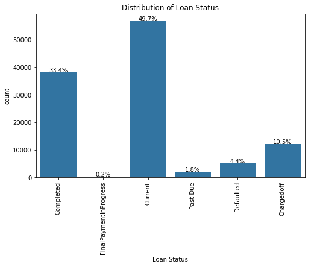

```python
# Create annotations
status_count = df['loan_status'].value_counts()
n_count = df['loan_status'].value_counts().sum()

base_color = sb.color_palette()[0]
plt.figure(figsize=[8, 5])
sb.countplot(data = df, x = 'loan_status', color = base_color)
# Get the tick locations and labels
locs, labels = plt.xticks(rotation=90)
# loop through each pair of locations and labels
for loc, label in zip(locs, labels):
    # get the text property for the label to get the correct count
    count = status_count[label.get_text()]
    pct_string = '{:0.1f}%'.format(100*count/n_count)
    # print the annotation just above the top of the bar
    plt.text(loc, count+200, pct_string, ha = 'center', color = 'black')
plt.title('Distribution of Loan Status')
plt.xlabel('Loan Status');
```

From the above chart, we see that about half of the loans are current, one-third are completed while 10.5% are charged-off loans.

### How is Credit Rating Distributed?

Next, let us review how credit rating, being the second main variable of this analysis, is distributed.

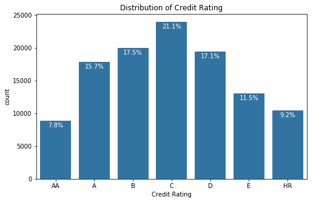

```python
# Plot ordinal distribution of credit rating
plt.figure(figsize=[8, 5])
sb.countplot(data = df, x = 'credit_rating', color = base_color)
plt.title('Distribution of Credit Rating')
plt.xlabel('Credit Rating');
# Add annotations by create a loop
rating_counts = df['credit_rating'].value_counts()
for i in range(rating_counts.shape[0]):
    count = rating_counts[i]
    pct_string = '{:0.1f}%'.format(100*count/n_count)
    # print the annotation just below the top of the bar
    plt.text(i, count-1000, pct_string, ha = 'center', color = 'white');
plt.show()
```

From the above plot, the rating is distributed normally. We see a modal credit rating of C at 21%, a high risk rating HR at 9.2% and the highest credit rating AA at 7.8%.

### What is the Distribution of Loan Amount?

Moving on to numerical variables, how is loan amount distributed?

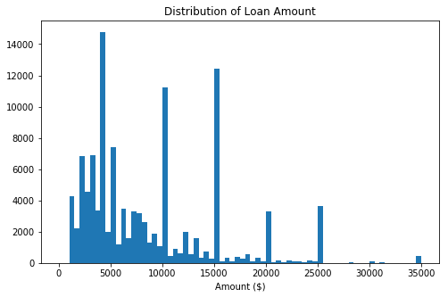

```python
# Start with a standard-scaled plot
binsize = 500
bins = np.arange(0, df['amount'].max()+binsize, binsize)
plt.figure(figsize=[8, 5])
plt.hist(data = df, x = 'amount', bins = bins)
plt.xlabel('Amount ($)')
plt.title('Distribution of Loan Amount')
plt.show();
```

Let's plot the loan amount again with a log-scale as there is some hidden distribution at the tail end.

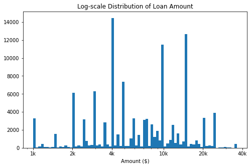

```python
# Plotting on a log-scale on the x-axis
log_binsize = 0.02
bins = 10 ** np.arange(3, np.log10(df['amount'].max())+log_binsize, log_binsize)
plt.figure(figsize=[8, 5])
plt.hist(data = df, x = 'amount', bins = bins)
plt.xscale('log')
plt.xticks([1e3, 2e3, 4e3, 1e4, 2e4, 4e4], ['1k', '2k', '4k', '10k', '20k', '40k'])
plt.xlabel('Amount ($)')
plt.title('Log-scale Distribution of Loan Amount')
plt.show();
```

From the log-scale, the log-scale shows many spikes with much precision at certain round sums such as 1,000, 2,000, 3,000 etc. It peaked at 4,000 and trailed off quickly to the next spike. It is expected that loans applied for would be at round sums, so this distribution makes sense.

### What is the Distribution of Borrower's APR and Rate?

Next, I'll look at the distribution of borrower's annual percentage rate (borrower's APR) and borrower's rate (interest rate).

```python
# Create a function to plot numeric variables as percentage
def as_percent(df, column): # df is the dataset and column is the variable
    percent = (df[column].dropna().values)*100
    bins = np.arange(0, df[column].max()*100+binsize, binsize)
    plt.figure(figsize=[8, 5])
    plt.hist(x = percent, bins = bins)
    labels = ['{}'.format(v) for v in ticks]
    plt.xticks(ticks, labels)
    plt.xticks(rotation = 20)
```

First, I will start with the distribution of borrower's APR.

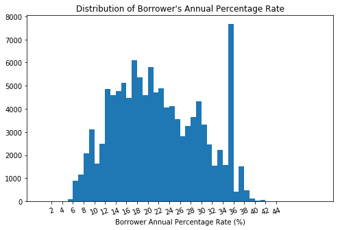

```python
# Plot the distribution of borrower's APR as percentage
binsize = 1
ticks = np.arange(2, 45 , 2)
as_percent(df, 'borrower_apr')
plt.xlabel('Borrower Annual Percentage Rate (%)')
plt.title("Distribution of Borrower's Annual Percentage Rate")
plt.show();
```

Next, what is the distribution of borrower's rate?

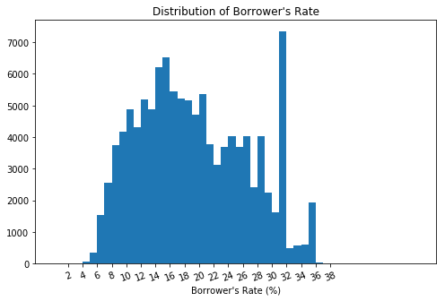

```python
# Plot the distribution of borrower's rate as percentage
binsize = 1
ticks = np.arange(2, 40 , 2)
as_percent(df, 'borrower_rate')
plt.xlabel("Borrower's Rate (%)")
plt.title("Distribution of Borrower's Rate")
plt.show();
```

Both borrower's APR and interest rate have similar distribution which is almost normal and unimodal except for a spike at 35% and 31% for borrower's APR and interest rate respectively. Borrower's rate is borrower's annual percentage rate less service fees, hence, the similar distribution.

### How is Debt-to-Income Ratio Distributed?

Next, the distribution of debt-to-income ratio would be plotted.

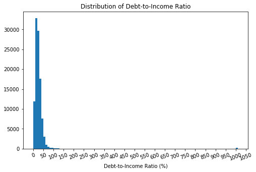

```python
# Plot the debt-to-income ratio as percentage
binsize = 10
ticks = np.arange(0, 1100 , 50)
as_percent(df, 'debt_to_income_ratio')
plt.xlabel('Debt-to-Income Ratio (%)')
plt.title('Distribution of Debt-to-Income Ratio')
plt.show();
```

The above distribution is very narrow and highly right-skewed. This is because debt-to-income ratio is highly ranged from 0 to 10.01, however most values are less than 50%. I would split the data at 50% and consider them separately.

```python
# Create a data set for debt-to-income ratio less than 50%
df_min = df['debt_to_income_ratio'] < 0.5
df_dtimin = df.loc[df_min,:]
```

```python
# Create a data set for debt-to-income ratio of 50% and above
df_max = (df['debt_to_income_ratio'] >= 0.5) & (df['debt_to_income_ratio'] <= 10.01)
df_dtimax = df.loc[df_max,:]
```

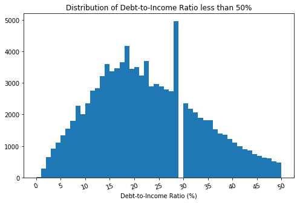

```python
# Plot the distribution of debt-to-income ratio less than 50%
binsize = 1
ticks = np.arange(0, 55 , 5)
as_percent(df_dtimin, 'debt_to_income_ratio')
plt.xlabel('Debt-to-Income Ratio (%)')
plt.title('Distribution of Debt-to-Income Ratio less than 50%')
plt.show();
```

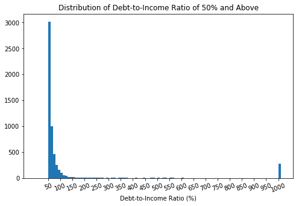

```python
# Plot the distribution of debt-to-income ratio of 50% and above
binsize = 10
ticks = np.arange(50, 1050 , 50)
as_percent(df_dtimax, 'debt_to_income_ratio')
plt.xlabel('Debt-to-Income Ratio (%)')
plt.title('Distribution of Debt-to-Income Ratio of 50% and Above')
plt.show();
```

For debt-to-income ratio less than 50%, we see an interesting normal distribution with a spike at 29% which similar to the plots of borrower's APR/rate. While, for that of 50% and above, it is very narrow and highly right-skewed and ranged to end with a short spike at 1001%.

### What is the Distribution of Stated Monthly Income?

Now let's plot the distribution of the last numeric variable: stated monthly income.

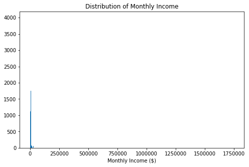

```python
# Plot the monthly income in a standard scale
binsize = 100
bins = np.arange(0, df['monthly_income'].max()+binsize, binsize)
plt.figure(figsize=[8, 5])
plt.hist(data = df, x = 'monthly_income', bins = bins)
plt.xlabel('Monthly Income ($)')
plt.title('Distribution of Monthly Income')
plt.show();
```

Much details cannot be seen as the distribution is very narrow, highly-skewed and there are outliers as high as 1,750,000. So, lets plot it in a log-scale and exclude the outliers as well by limiting the x-axis to 50,000.

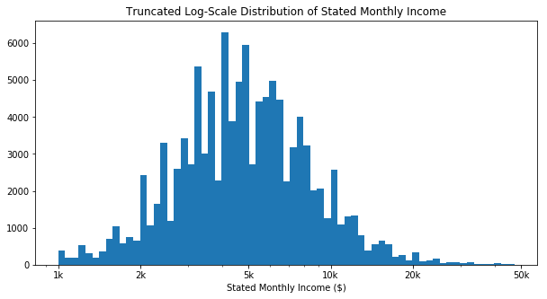

```python
# Plot  using log-scale and truncate the x-axis to show only values less than 50k which makes the majority of data
log_binsize = 0.025
bins = 10 ** np.arange(3, 4.7, log_binsize)
plt.figure(figsize=[10, 5])
plt.hist(data = df, x = 'monthly_income', bins = bins)
plt.xscale('log')
plt.xticks([1e3, 2e3, 5e3, 1e4, 2e4, 5e4], ['1k', '2k','5k', '10k', '20k', '50k'])
plt.xlabel('Stated Monthly Income ($)')
plt.title('Truncated Log-Scale Distribution of Stated Monthly Income')
plt.show();
```

From the truncated log-scale, the distribution can be better interpreted as normal. It peaked at an income of 4,000 with 5,000 following closely with a lot of spikes at round sums as expected.

### What is the Distribution of Loan Term?

Next we move to categorical variables, I would start with the distribution of loan term.

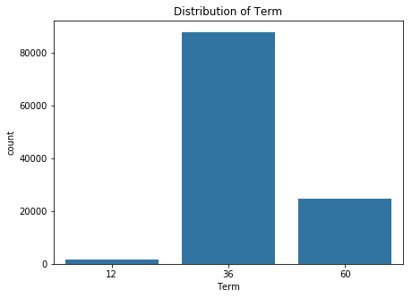

```python
# Plot term distribution
base_color = sb.color_palette()[0]
plt.figure(figsize=[7, 5])
sb.countplot(data = df, x = 'term', color = base_color)
plt.xlabel('Term')
plt.title('Distribution of Term');
```

Loans have a tenor of 1year, 3years or 5years but most loans are 3-year termed.

### How is Listing Category Distributed?

Next, the loan listing category distribution.

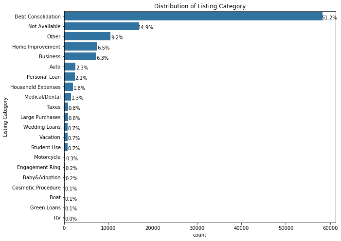

```python
# Plot the distribution of listing category
type_order = df['listing_category'].value_counts().index
plt.figure(figsize=[10, 8])
sb.countplot(data = df, y = 'listing_category', color = base_color, order = type_order)
plt.ylabel('Listing Category')
plt.title('Distribution of Listing Category')
# Add annotations
cat_counts = df['listing_category'].value_counts()
locs, labels = plt.yticks() # get the current tick locations and labels
# loop through each pair of locations and labels
for loc, label in zip(locs, labels):
    # get the text property for the label to get the correct count
    count = cat_counts[label.get_text()]
    pct_string = '{:0.1f}%'.format(100*count/n_count)
    # print the annotation just below the top of the bar
    plt.text(count+1500, loc+0.3,  pct_string, ha = 'center', color = 'black');
```

Debt consolidation at 51% was the highest loan listing category. It is the most popular type of Prosper's loans and makes it seem that borrowers take loan to pay off other loans. Home improvement and Business are other notable categories in this loan variable.

### How is Occupation distributed?

Occupation distribution is the next to be analyzed.

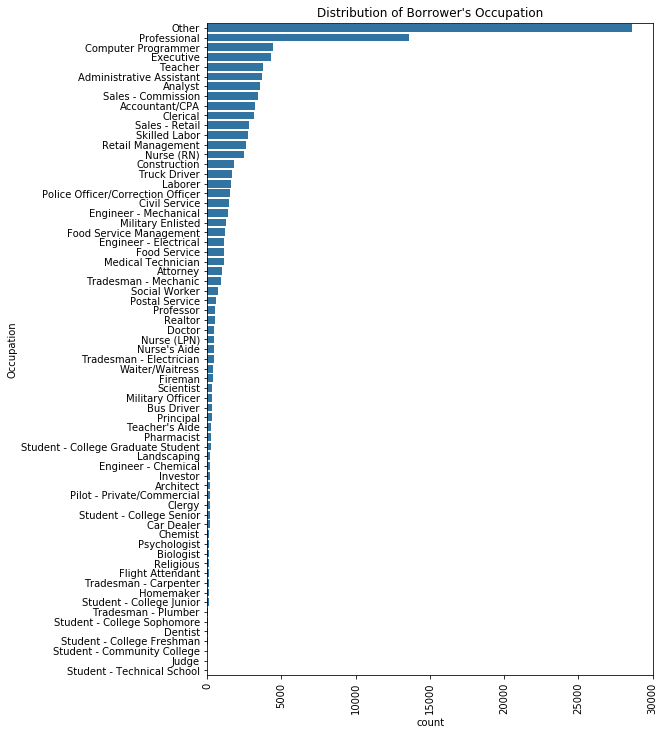

```python
# Show the distribution of borrower's occupation
type_order = df['occupation'].value_counts().index
plt.figure(figsize=[8, 12])
plt.xticks(rotation=90)
sb.countplot(data = df, y = 'occupation', color = base_color, order = type_order)
plt.title("Distribution of Borrower's Occupation")
plt.ylabel('Occupation');
```

Most borrowers on Prosper indicated to be professionals, computer programmers, administrative assistanta, executives, teacher and analysts. Students, judges, dentists and tradesmen are the least occupations taking loans.

### What is the Distribution of Borrower's State?

Next, would be the distribution of borrower's state.

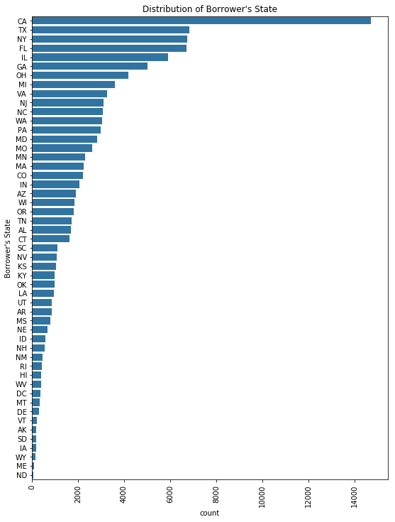

```python
# Plot the distribution of borrower's state
type_order = df['state'].value_counts().index
plt.figure(figsize=[9, 12])
plt.xticks(rotation=90)
sb.countplot(data = df, y = 'state', color = base_color, order = type_order)
plt.title("Distribution of Borrower's State")
plt.ylabel("Borrower's State");
```

### How is Income Range Distributed?

Borrower's income range distribution would be plotted next.

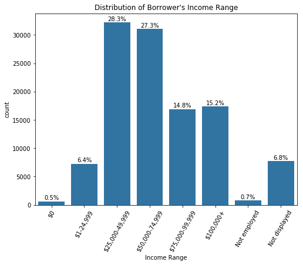

```python
# Show the income range distribution
base_color = sb.color_palette()[0]
plt.figure(figsize=[8, 6])
sb.countplot(data = df, x = 'income_range', color = base_color)
plt.xlabel('Income Range')
plt.title("Distribution of Borrower's Income Range")
plt.xticks(rotation=60)
# Add annotations
cat_counts = df['income_range'].value_counts()
locs, labels = plt.xticks() # get the current tick locations and labels
# loop through each pair of locations and labels
for loc, label in zip(locs, labels):
    # get the text property for the label to get the correct count
    count = cat_counts[label.get_text()]
    pct_string = '{:0.1f}%'.format(100*count/n_count)
    # print the annotation just below the top of the bar
    plt.text(loc, count+300,  pct_string, ha = 'center', color = 'black');
```

25,000-49,999 is the income range of borrowers with the most loans at 28.3% followed closely by 50,000-74,999 at 27.3%.

### What is the DIstribution of Employment Status?

Finally for univariate exploration, we would visualize employment status.

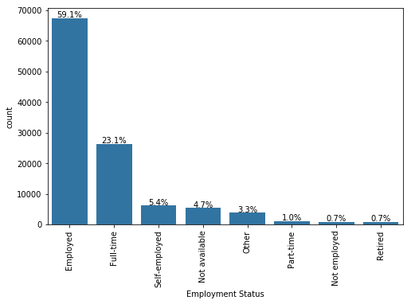

```python
# Plot the distribution of employment status
type_order = df['employment_status'].value_counts().index
plt.figure(figsize=[8, 5])
plt.xticks(rotation=90)
sb.countplot(data = df, x = 'employment_status', color = base_color, order = type_order)
plt.xlabel('Employment Status')
# Add annotations
cat_counts = df['employment_status'].value_counts()
locs, labels = plt.xticks() # get the current tick locations and labels
# loop through each pair of locations and labels
for loc, label in zip(locs, labels):
    # get the text property for the label to get the correct count
    count = cat_counts[label.get_text()]
    pct_string = '{:0.1f}%'.format(100*count/n_count)
    # print the annotation just below the top of the bar
    plt.text(loc, count+300, pct_string, ha = 'center', color = 'black');
```

Most borrowers are employed which makes sense as they have a source of income for loan payment.

### Discuss the distribution(s) of your variable(s) of interest. Were there any unusual points? Did you need to perform any transformations?

For loan status variable, past due delinquency bucket was consolidated. Thereafter, the variable was changed into ordinal category datatype in increasing order of default. About half of the loans are current, one-third are completed, 4.4% defaulted and 10.5% are charged-off loans.

While credit rating (which is a variable introduced by merging credit grade and Prosper rating), was also changed to ordinal category datatype in ascending order of rating. The credit rating is distributed normally across the order from HR to AA. We see a modal rating C at 21%, a low credit rating HR at 9.2% and the highest credit rating AA at 7.8%.

### Of the features you investigated, were there any unusual distributions? Did you perform any operations on the data to tidy, adjust, or change the form of the data? If so, why did you do this?

Most of the numerical variables had unusual distributions except for borrower's APR and rate which had similar, almost normal-unimodal distributions except for lone spikes at 35% and 31% respectively.

For loan original amount and stated monthly income which had long-tailed, skewed distributions, log-scaled charts were plotted to expose spikes of rounded sums with much precision. Stated monthly income had high range of outliers so the axis was limited to 50,000 while loan original amount revealed major peaks at 4,000, 10,000 and 15,000.

Debt-to-income ratio was highly ranged and most of the distribution was was less than 50%, hence, it was split in two at 50% and plotted separately. The categorical variables did not need any form of adjustment.

## Bivariate Exploration

### How do Numerical Variables Relate with Each Other?

To begin, I will investigate the relationships between numerical variables to see if any particular pairs have strong correlations.

```python
# Create a list for numeric variables
numeric_var = ['borrower_apr', 'borrower_rate', 'debt_to_income_ratio', 'amount', 'monthly_income']
```

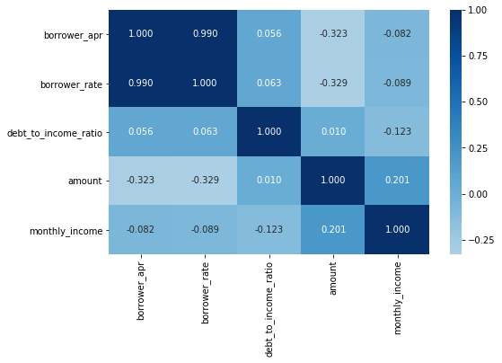

```python
# Correlation plot of numeric variables
plt.figure(figsize = [8, 5])
sb.heatmap(df[numeric_var].corr(), annot = True, fmt = '.3f',
           cmap = 'Blues', center = 0)
plt.show()
```

```
df.shape= (113937, 13)
df_sample.shape= (1000, 13)
```

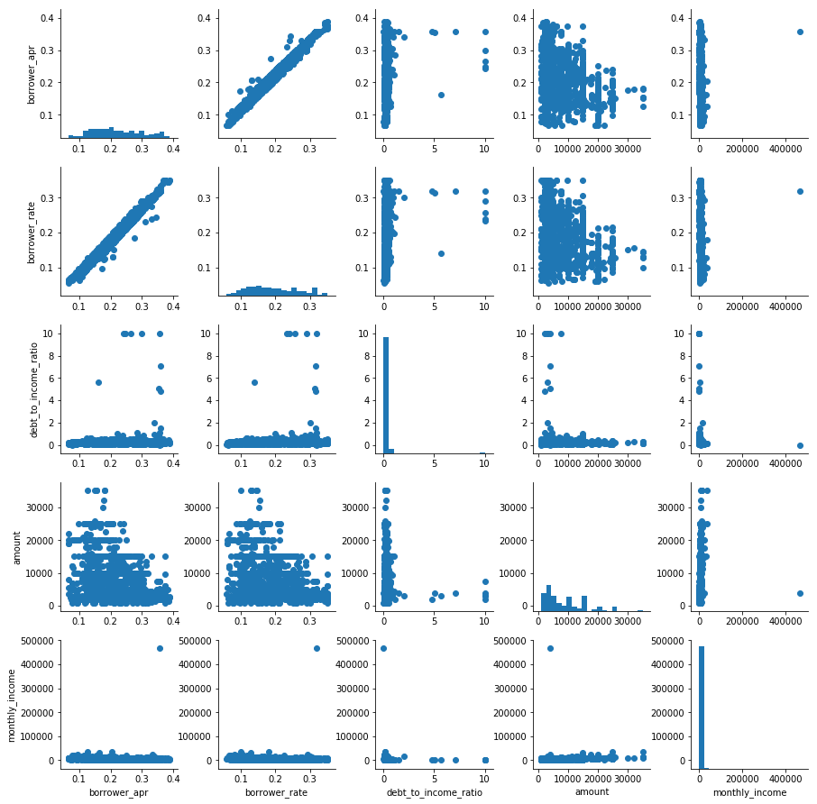

```python
# Plot matrix: sample 1000 loans so that plots are clearer and they render faster
print("df.shape=",df.shape)
df_sample = df.dropna().sample(n=1000, replace = False)
print("df_sample.shape=",df_sample.shape)

g = sb.PairGrid(data = df_sample, vars = numeric_var)
g = g.map_diag(plt.hist, bins = 20)
g.map_offdiag(plt.scatter);
```

Based on the correlation matrix and the scatter plots above, there are some relationships of interest. As expected, there is a strong relationship between borrower's rate and borrower's APR (correlation coefficient of 0.990). This is because borrower's rate is borrower's APR less service fees. Moreover, there is a moderately negative correlation between borrower's APR/rate and loan amount. It can be understood that higher loan amounts have lower interest rates. On the other hand, loan amount and stated monthly income have a mild positive correlation and it is expected that they should move proportionally. Debt-to-income ratio does not have any relevant correlation with other numeric variables.

### How do Numerical Variables Interact with Categorical Variables?

Let's move on to look at how these numerical variables correlate with the categorical and ordinal variables.

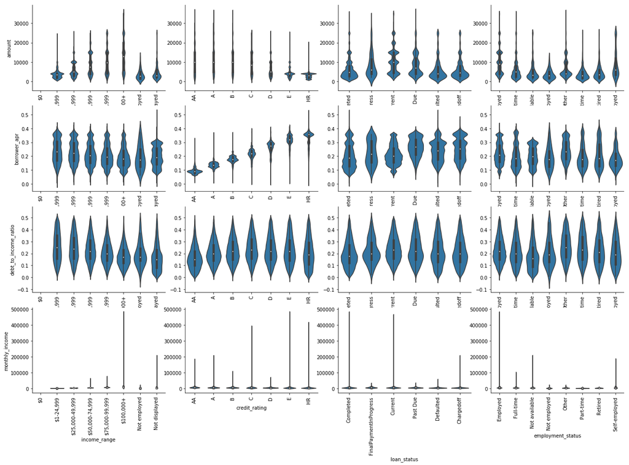

```python
# Plot matrix of numeric features against categorical features using violin plots
def violingrid(x, y, **kwargs):
    sb.violinplot(x=x, y=y, color=base_color)

plt.figure(figsize = [10, 10]);
g = sb.PairGrid(data = df_dtimin, y_vars = ['amount', 'borrower_apr', 'debt_to_income_ratio', 'monthly_income'],
                x_vars = ['income_range', 'credit_rating', 'loan_status', 'employment_status'], size = 3,
                aspect = 1.5)
g.map(violingrid)
for ax in g.axes.flatten():
    ax.tick_params(axis = 'x', rotation = 90)
plt.show();
```

Interestingly, it appears that there are some relationships between the categorical variables and the numeric variables (borrower rate not included because of the similarity with borrower APR).

> Credit Rating: Violin plots show that there is a positive correlation of borrower APR across the rating from AA to HR (High to Low). And inversely, a negative correlation of amount across the credit rating. Loans with high credit ratings have higher amounts with lower interest rates. It is important to note that amount, borrower APR and by extension borrower rate have a high effect on credit rating. There is no meaningful relationship with stated monthly income as we cannot ascertain much from the plot (due to wide range of distribution). Debt-to-income ratio was limited to values less than 0.5 so we could observe an almost even distribution with a slight drop at AA rating.

> Loan Status: Chargedoff, defaulted and past due loans are seen to have higher borrower APR than others. The higher rates might be said to be affecting repayment which is a point to note. Loan amount on the average is lower for the loans that are delinquent. Debt-to-income ratio and stated monthly income have no relevant impact across the loan status except for a wide range of monthly income for current loans (probably as a result of outliers).

### How Does Income Range Affect Loan Status and Credit Rating?

Next, I would look at the relationship between our main features (loan status and credit rating) and income range.

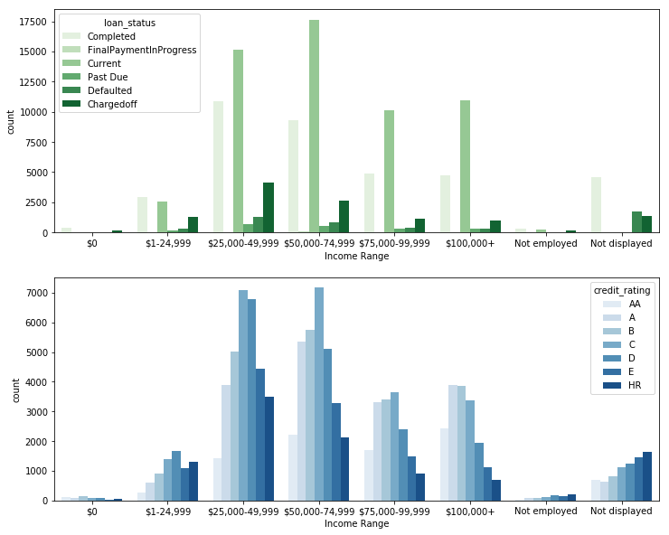

```python
# since there's only three subplots to create, using the full data should be fine.
plt.figure(figsize = [12, 10])

# subplot 1: Loan status vs. Income Range
plt.subplot(2, 1, 1)
sb.countplot(data = df, x = 'income_range', hue = 'loan_status', palette = 'Greens')
plt.xlabel('Income Range')

# subplot 2: Credit rating vs. Income Range
ax = plt.subplot(2, 1, 2)
sb.countplot(data = df, x = 'income_range', hue = 'credit_rating', palette = 'Blues')
plt.xlabel('Income Range');
```

> Loan Status: Deliquent loans are seen to be mostly represented in the lower income range especially 25,000-49,999, 50,000-74,999 and 1-24,999. Chargedoff and Defaulted loans are also represented in the Not displayed category. I would recommend that borrowers state their income range as it is seen to affect the loan status. It can be said that most of the borrowers in this category may not be income earners.

> Credit Rating: From the above plot, credit rating shows a similar relationship as loan status above. For Not displayed category, we see a incline in credit ratings. Lower credit ratings are highly represented in lower income ranges and consequently, higher income ranges show better credit ratings.

### How Does Term Affect Loan Status and Credit Rating?

In like manner, I would plot the interaction between the main features (loan status and credit rating) and term.

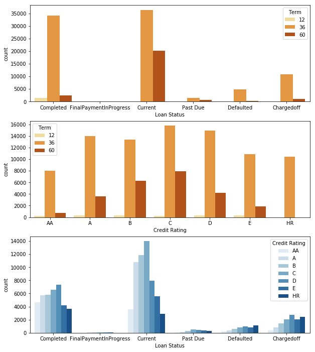

```python
# since there's only three subplots to create, using the full data should be fine.
plt.figure(figsize = [10, 12])

# subplot 1: loan status vs. term
plt.subplot(3, 1, 1)
sb.countplot(data = df, x = 'loan_status', hue = 'term', palette = 'YlOrBr')
plt.xlabel('Loan Status')
plt.legend(ncol = 1, title='Term')

# subplot 2: credit rating vs. term
ax = plt.subplot(3, 1, 2)
sb.countplot(data = df, x = 'credit_rating', hue = 'term', palette = 'YlOrBr')
plt.xlabel('Credit Rating')
ax.legend(ncol = 1, title='Term') # re-arrange legend to reduce overlapping

# subplot 3: loan status vs. credit rating, use different color palette
ax = plt.subplot(3, 1, 3)
sb.countplot(data = df, x = 'loan_status', hue = 'credit_rating', palette = 'Blues')
plt.xlabel('Loan Status')
plt.legend(ncol = 1, title='Credit Rating')

plt.show();
```

> As for the relationship between term and credit rating: 3-year termed loans show an almost normal distribution across ratings AA to HR; 1-year termed loans is distributed evenly across all ratings (AA to E) except HR where it is insignificant; and similarly 5-year termed loans is insignificant in HR but normally distributed across from AA to E.

> For the relationship between loan status and credit rating, it can be seen that most of the delinquent loans have poor rating. For example, from the plot we see that the lowest rating HR is very significant among Defaulted loan status as well as Chargedoff. There is a decline across ratings for Chargedoff and Defaulted status. While the ratings of other loan status categories show a seemingly normal distribution from AA to HR (except for FinalPaymentInProgess which is seemingly insignificant).

### How Does Amount & Monthly Income Interact With Loan Status & Credit Rating?

Let us take a look at the bivariate relationships between our main variables (loan status and credit rating) and two numeric variables: loan amount and stated monthly income. We would plot the amount and monthly income on a log-scale so we can see the distribution clearly.

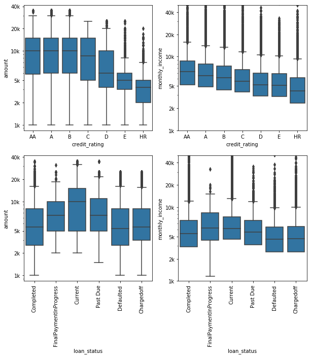

```python
plt.figure(figsize = [10, 10])

plt.subplot(2, 2, 1)
sb.boxplot(data=df, x='credit_rating', y='amount', color=base_color)
plt.yscale('log')
plt.yticks([1e3, 2e3, 4e3, 1e4, 2e4, 4e4], ['1k', '2k', '5k', '10k', '20k', '40k'])

plt.subplot(2, 2, 2)
sb.boxplot(data=df, x='credit_rating', y='monthly_income', color=base_color)
plt.ylim(1e3, 5e4)
plt.yscale('log')
plt.yticks([1e3, 2e3, 4e3, 1e4, 2e4, 4e4], ['1k', '2k', '5k', '10k', '20k', '40k'])

plt.subplot(2, 2, 3)
sb.boxplot(data=df, x='loan_status', y='amount', color=base_color)
plt.yscale('log')
plt.yticks([1e3, 2e3, 4e3, 1e4, 2e4, 4e4], ['1k', '2k', '5k', '10k', '20k', '40k'])
plt.xticks(rotation=90)

plt.subplot(2, 2, 4)
sb.boxplot(data=df, x='loan_status', y='monthly_income', color=base_color)
plt.ylim(1e3, 5e4)
plt.yscale('log')
plt.yticks([1e3, 2e3, 4e3, 1e4, 2e4, 4e4], ['1k', '2k', '5k', '10k', '20k', '40k'])
plt.xticks(rotation=90);
```

> Loan Status: For this variable, we see Current loans having the highest median loan amount which is similar in the plot for stated monthly income with FinalPaymentInProgress. Chargedoff and Defaulted loans have similar median amount and stated monthly income. As observed in the second plot for credit rating, bottom whiskers are absent except for FinalPaymentInProgress.

### What is the Relationship Between Borrower's APR and Listing Category?

Finally, a plot to see how borrower's APR relates with loan listing category.

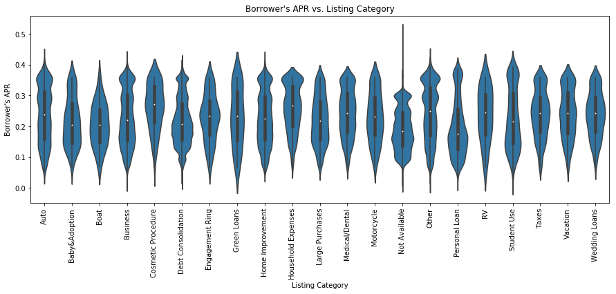

```python
# Create a violin plot to show relationship between listing category and borrower's APR
plt.figure(figsize = [15, 5])
sb.violinplot(data=df, x='listing_category', y='borrower_apr', color=base_color)
plt.title("Borrower's APR vs. Listing Category")
plt.xlabel('Listing Category')
plt.ylabel("Borrower's APR")
plt.xticks(rotation=90);
```

From the violin plot, we can see that Cosmetic Procedure and Household Expenses are listed with higher borrower's APR than other categories while Personal loans are listed with the lowest APR.

### Talk about some of the relationships you observed in this part of the investigation. How did the feature(s) of interest vary with other features in the dataset?

Looking at the main variables credit rating and loan status, there are a lot of observations as to how they relate with other loan featuures and each other. This would be discussed individually in this section.

##### Credit Rating vs Loan Status

For the relationship between loan status and credit rating, it can be seen that most of the delinquent loans have poor rating. For example, the lowest rating HR is very significant among Defaulted loan status as well as Chargedoff and there is a decline across ratings for Chargedoff and Defaulted status. While the ratings of other loan status categories show a seemingly normal distribution from HR to AA (except for FinalPaymentInProgess which is seemingly insignificant).

## Multivariate Exploration

My main focus in this section is to see how other features affect the loan status and credit rating together. In order to do this, I will create plots of three or more variables to investigate the determinants of loan status and credit rating.

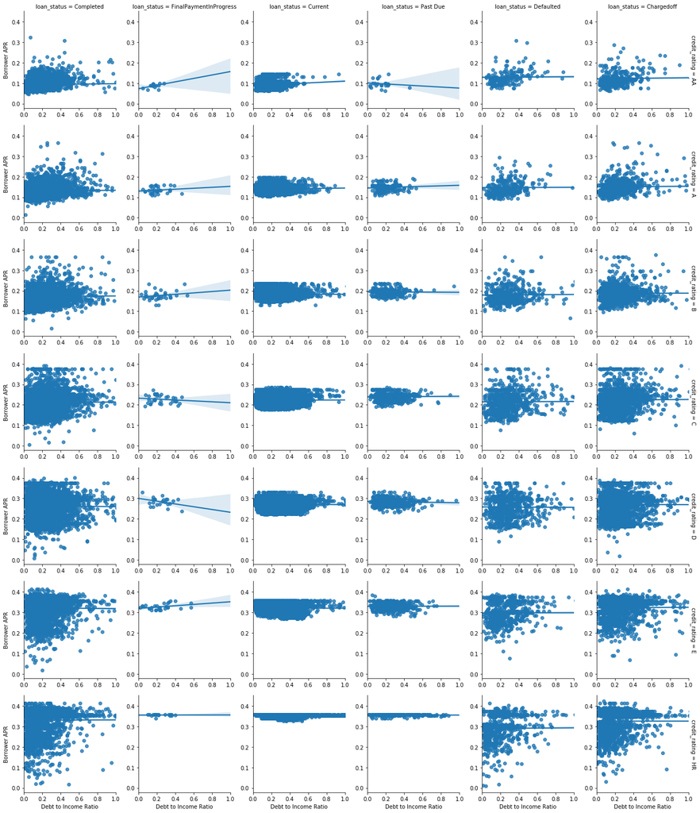

```python
g = sb.FacetGrid(df, col="loan_status",  row="credit_rating", xlim = [0,1], margin_titles=True)
g.map_dataframe(sb.regplot, "debt_to_income_ratio", "borrower_apr")
g.set_xlabels('Debt to Income Ratio')
g.set_ylabels('Borrower APR')

plt.show();
```

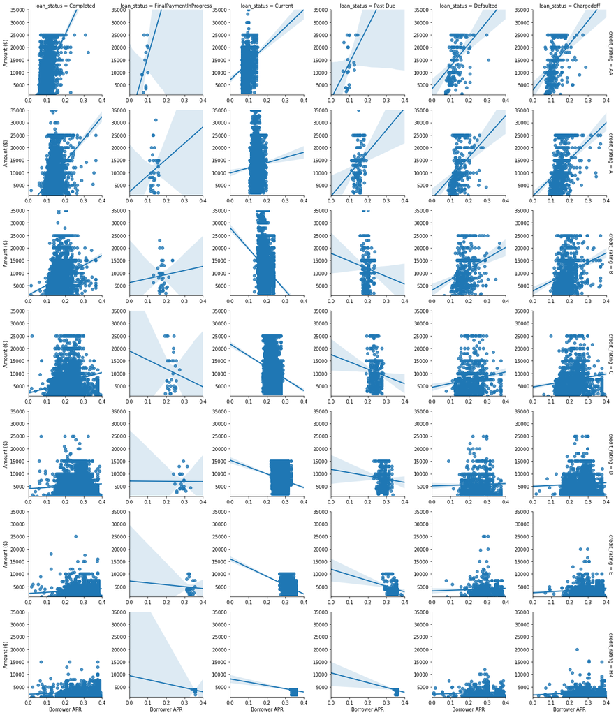

```python
g = sb.FacetGrid(df, col="loan_status", row="credit_rating", xlim = [0, 0.4], ylim = [1000, 35000], margin_titles=True)
g.map_dataframe(sb.regplot, "borrower_apr", "amount")
g.set_xlabels('Borrower APR')
g.set_ylabels('Amount ($)')

plt.show();
```

In the following chats, we would closely at the impact of amount and borrower's APR on these main variables.

### How Does Loan Amount affect Credit Rating & Loan Status?

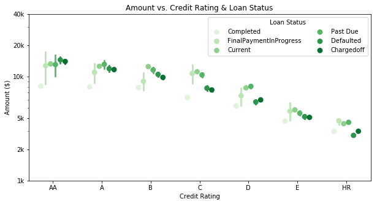

```python
fig = plt.figure(figsize = [10,5])
ax = sb.pointplot(data = df, x = 'credit_rating', y = 'amount', hue = 'loan_status',
           palette = 'Greens', linestyles = '', dodge = 0.5)
plt.title('Amount vs. Credit Rating & Loan Status')
plt.yscale('log')
plt.yticks([1e3, 2e3, 4e3, 1e4, 2e4, 4e4], ['1k', '2k', '5k', '10k', '20k', '40k'])
plt.ylabel('Amount ($)')
plt.xlabel('Credit Rating')
plt.legend(loc = 1, ncol = 2, title='Loan Status') # re-arrange legend to remove overlapping
plt.show();
```

In the pointplot chart above, we see clearly how amount affects our major features. The decreasing trend of loan amount across ratings is evident.

### Borrower APR vs. Credit Rating & Loan Status

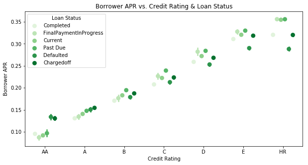

```python
fig = plt.figure(figsize = [10,5])
ax = sb.pointplot(data = df, x = 'credit_rating', y = 'borrower_apr', hue = 'loan_status',
           palette = 'Greens', linestyles = '', dodge = 0.5)
plt.title('Borrower APR vs. Credit Rating & Loan Status')
plt.ylabel('Borrower APR')
plt.xlabel('Credit Rating')
plt.legend(loc = 2, title='Loan Status')
plt.show();
```

From this chart, we see clearly the incline in borrower's APR across ratings.

### Talk about some of the relationships you observed in this part of the investigation. Were there features that strengthened each other in terms of looking at your feature(s) of interest?

Loans with high credit ratings have borrower's APR less than 20%. Borrower's APR is thus a determinant factor in credit rating which was clearly shown in this section. It can also be seen that loan amount is a significant factor in computing credit rating. Loans with low amount have low ratings and those with high amounts have higher ratings.

### Were there any interesting or surprising interactions between features?

I observed that Completed loan status does not have any unique interaction with other features. This is probably because it is a combination of both loans that defaulted at some point and those that did not. For example, in its relationship with loan amount, it is seen to appear among the least across ratings. Also it is seen most times, to have a low APR when compared with other loan status categories across credit ratings.

## Conclusions

In this Prosper loan data exploration, the relationship between our main variables credit rating and loan status is significant. It was observed that most of the delinquent loans have poor rating as the lowest rating HR is evident among Defaulted loan status as well as Chargedoff and there is a decline across ratings for Chargedoff and Defaulted status.

For credit rating, I also observed a strong relationship with other features such as borrower's APR, amount and income range. There is a negative correlation of borrower's APR across the ratings from HR to AA and a positive correlation for amount. Thus highly rated loans have higher amounts with lower interest rates. For income range, lower credit ratings are highly represented in lower income ranges, thus, higher income ranges show better credit ratings.